# CUSTOMER SEGMENTATION

### What is customer segmentation all about

Customer Segmentation is process of dividing customers into different groups based on common features so companies can well position their products and services in the market for each of the discovered groups in the data.

### What is the data ?

2000 customer purchases from a store's database.

### Import Libraries

```python
import os
import pandas as pd
import numpy as np
import scipy
# for visualisations
import matplotlib.pyplot as plt
%matplotlib inline
import seaborn as sns
sns.set()
# for standardization
from sklearn.preprocessing import StandardScaler
# for hierarchical clustering
from scipy.cluster.hierarchy import dendrogram,linkage
# for k-means clustering
from sklearn.cluster import KMeans
# for PCA
from sklearn.decomposition import PCA
# export data
import pickle
```

```python
os.getcwd()
```

```
'C:\\Users\\Wale'
```

```python
os.chdir('C:\\Users\\Wale')
```

```python
df_seg = pd.read_csv('segmentation data.csv')
```

## Data Cleaning

```python
df_seg.head(10)
```

|  | ID | Sex | Marital status | Age | Education | Income | Occupation | Settlement size |
| --- | --- | --- | --- | --- | --- | --- | --- | --- |
| 0 | 100000001 | 0 | 0 | 67 | 2 | 124670 | 1 | 2 |
| 1 | 100000002 | 1 | 1 | 22 | 1 | 150773 | 1 | 2 |
| 2 | 100000003 | 0 | 0 | 49 | 1 | 89210 | 0 | 0 |
| 3 | 100000004 | 0 | 0 | 45 | 1 | 171565 | 1 | 1 |
| 4 | 100000005 | 0 | 0 | 53 | 1 | 149031 | 1 | 1 |
| 5 | 100000006 | 0 | 0 | 35 | 1 | 144848 | 0 | 0 |
| 6 | 100000007 | 0 | 0 | 53 | 1 | 156495 | 1 | 1 |
| 7 | 100000008 | 0 | 0 | 35 | 1 | 193621 | 2 | 1 |
| 8 | 100000009 | 0 | 1 | 61 | 2 | 151591 | 0 | 0 |
| 9 | 100000010 | 0 | 1 | 28 | 1 | 174646 | 2 | 0 |

```python
categoricalColumn = ['Sex', 'Marital status', 'Occupation', 'Settlement size']

for col in categoricalColumn:
    print('Value Counts for ' + col)
    print(df_seg[col].value_counts())
    print('')
```

```
Value Counts for Sex
0    1086
1     914
Name: Sex, dtype: int64

Value Counts for Marital status
0    1007
1     993
Name: Marital status, dtype: int64

Value Counts for Occupation
1    1113
0     633
2     254
Name: Occupation, dtype: int64

Value Counts for Settlement size
0    989
1    544
2    467
Name: Settlement size, dtype: int64
```

```python
# Drop ID Column
df_seg = df_seg.drop(['ID'], axis=1)
```

```python
df_seg.info()
```

```
<class 'pandas.core.frame.DataFrame'>
RangeIndex: 2000 entries, 0 to 1999
Data columns (total 7 columns):
 #   Column           Non-Null Count  Dtype
---  ------           --------------  -----
 0   Sex              2000 non-null   int64
 1   Marital status   2000 non-null   int64
 2   Age              2000 non-null   int64
 3   Education        2000 non-null   int64
 4   Income           2000 non-null   int64
 5   Occupation       2000 non-null   int64
 6   Settlement size  2000 non-null   int64
dtypes: int64(7)
memory usage: 109.5 KB
```

There are no missing values in the data, so we move forward into exploratory analysis.

## Exploratory Analysis

```python
df_seg.describe()
```

|  | Sex | Marital status | Age | Education | Income | Occupation | Settlement size |
| --- | --- | --- | --- | --- | --- | --- | --- |
| count | 2000.000000 | 2000.000000 | 2000.000000 | 2000.00000 | 2000.000000 | 2000.000000 | 2000.000000 |
| mean | 0.457000 | 0.496500 | 35.909000 | 1.03800 | 120954.419000 | 0.810500 | 0.739000 |
| std | 0.498272 | 0.500113 | 11.719402 | 0.59978 | 38108.824679 | 0.638587 | 0.812533 |
| min | 0.000000 | 0.000000 | 18.000000 | 0.00000 | 35832.000000 | 0.000000 | 0.000000 |
| 25% | 0.000000 | 0.000000 | 27.000000 | 1.00000 | 97663.250000 | 0.000000 | 0.000000 |
| 50% | 0.000000 | 0.000000 | 33.000000 | 1.00000 | 115548.500000 | 1.000000 | 1.000000 |
| 75% | 1.000000 | 1.000000 | 42.000000 | 1.00000 | 138072.250000 | 1.000000 | 1.000000 |
| max | 1.000000 | 1.000000 | 76.000000 | 3.00000 | 309364.000000 | 2.000000 | 2.000000 |

#### Interpretation

1. The proportion of sexes in the data is almost even but we have more male customers.
2. The data comprises of younger customers between the ages of 20 to 45.
3. The income of customers is rightly skewed, so we have the mean falling to over 100k US dollars.
4. From the mean we can observe that most customers are skilled workers and unemployed.
5. Many of the customers live in the small and medium sized cities

```python
# correlation matrics
df_seg.corr()
```

|  | Sex | Marital status | Age | Education | Income | Occupation | Settlement size |
| --- | --- | --- | --- | --- | --- | --- | --- |
| Sex | 1.000000 | 0.566511 | -0.182885 | 0.244838 | -0.195146 | -0.202491 | -0.300803 |
| Marital status | 0.566511 | 1.000000 | -0.213178 | 0.374017 | -0.073528 | -0.029490 | -0.097041 |
| Age | -0.182885 | -0.213178 | 1.000000 | 0.654605 | 0.340610 | 0.108388 | 0.119751 |
| Education | 0.244838 | 0.374017 | 0.654605 | 1.000000 | 0.233459 | 0.064524 | 0.034732 |
| Income | -0.195146 | -0.073528 | 0.340610 | 0.233459 | 1.000000 | 0.680357 | 0.490881 |
| Occupation | -0.202491 | -0.029490 | 0.108388 | 0.064524 | 0.680357 | 1.000000 | 0.571795 |
| Settlement size | -0.300803 | -0.097041 | 0.119751 | 0.034732 | 0.490881 | 0.571795 | 1.000000 |

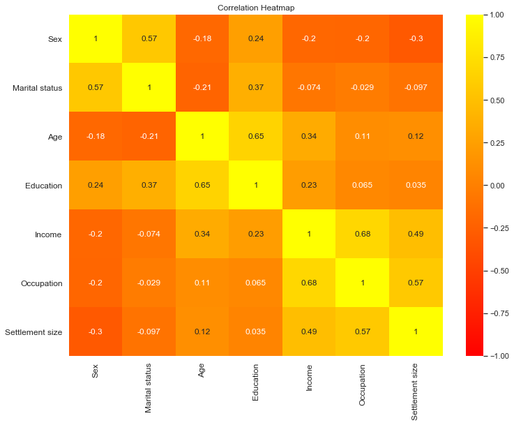

```python
# set the size of the plot
plt.figure(figsize = (12,9))
#heatmap
s = sns.heatmap(df_seg.corr(),
               annot = True,
               cmap= "autumn",
               vmin = -1,
               vmax = 1)
# label the graph
s.set_yticklabels(s.get_yticklabels(),rotation = 0, fontsize =12)
s.set_xticklabels(s.get_xticklabels(),rotation = 90, fontsize =12)
plt.title('Correlation Heatmap')
plt.show()
```

##### Interpretation

Here we have some of the data strongly correlated with one another and some other relationships are weak. It is great that we have these correlations because it helps in forming our clusters.

*Strongly correlated variables*

1. Marital Status and Sex - 0.57
2. Education and Age - 0.65
3. Income and Settlement Size - 0.49
4. Occupation and Settlement Size - 0.57
5. Income and Occupation - 0.68

### Scatter Plot

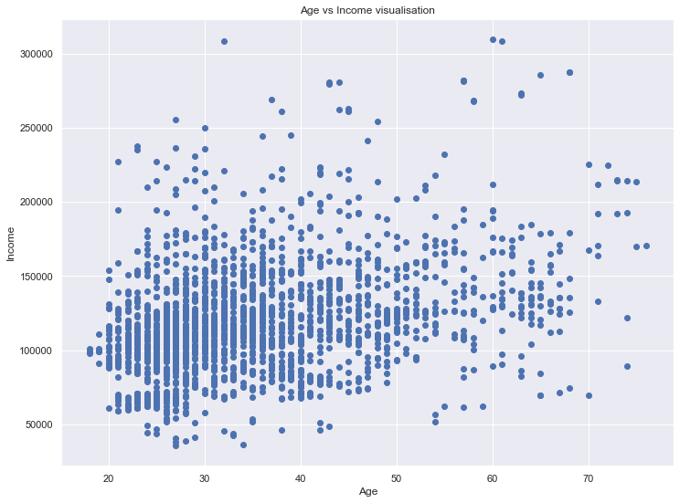

```python
plt.figure(figsize=(12,9))
plt.scatter(df_seg.iloc[:,2], df_seg.iloc[:,4])
plt.xlabel("Age")
plt.ylabel("Income")
plt.title('Age vs Income visualisation')
```

##### Interpretation

There is not exactly a linear relationship between the Ages and Income of customers as seen in the graph. The data is scattered at different points in the graph. It makes sense that they are not strongly correlated though, the older you get does not necessarily mean more money.

## Data Preprocessing

#### Standardization

Why is it important? I standardized the data so there is an equal treatment of features by the model

```python
scaler= StandardScaler()
seg_std= scaler.fit_transform(df_seg)
```

```python
seg_std
```

```
array([[-0.91739884, -0.99302433,  2.65361447, ...,  0.09752361,
         0.29682303,  1.552326  ],
       [ 1.09003844,  1.00702467, -1.18713209, ...,  0.78265438,
         0.29682303,  1.552326  ],
       [-0.91739884, -0.99302433,  1.11731585, ..., -0.83320224,
        -1.26952539, -0.90972951],
       ...,
       [-0.91739884, -0.99302433, -0.41898277, ..., -0.90695688,
        -1.26952539, -0.90972951],
       [ 1.09003844,  1.00702467, -1.01643224, ..., -0.60332923,
        -1.26952539, -0.90972951],
       [-0.91739884, -0.99302433, -0.93108232, ..., -1.3789866 ,
        -1.26952539, -0.90972951]])
```

## Unsupervised Learning Techniques

### Hierarchical Clustering

Hierarchical clustering is an unsupervised learning model used to group data by similarity with a dendrogram. It is an easy method to find the clusters in the data.

```python
hier_clust = linkage(seg_std, method = 'ward')
```

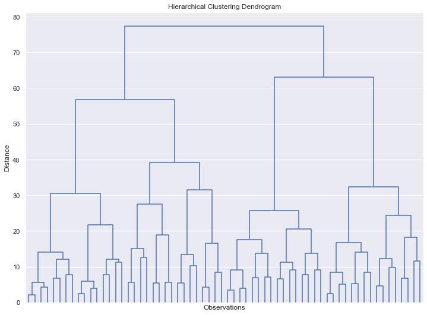

```python
plt.figure(figsize = (12,9))
plt.title('Hierarchical Clustering Dendrogram')
plt.xlabel('Observations')
plt.ylabel('Distance')
dendrogram(hier_clust,
           truncate_mode = 'level',
           p = 5,
           show_leaf_counts = False,
           no_labels = True,
           color_threshold = 0)
plt.show()
```

#### Finding the clusters

Find the longest vertical line form the dendrogram that intercepted by a horizontal line.This is where we make the cut and form the clusters. All we need to now is to remove the color threshold

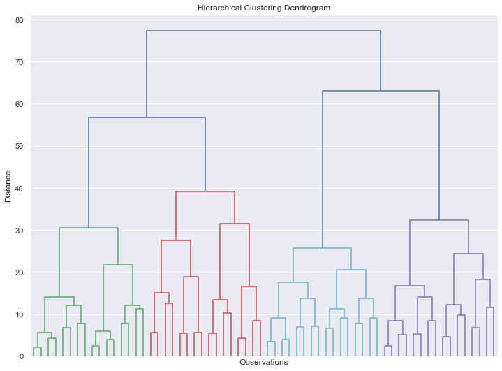

```python
# An easy way to identify the clusters is to take out the color threshold
plt.figure(figsize = (12,9))
plt.title('Hierarchical Clustering Dendrogram')
plt.xlabel('Observations')
plt.ylabel('Distance')
dendrogram(hier_clust,
           truncate_mode = 'level',
           p = 5,
           show_leaf_counts = False,
           no_labels = True)
plt.show()
```

We have 4 clusters in the dataset.

```
1. Cluster 1 = Green
2. Cluster 2 = Red
3. Cluster 3 = Light Blue
4. Cluster 4 = Purple
```

This clustering method is not very efficient with large datasets but its advantage is it finds the clusters in the data. So one can start with the hierarchical technique to discover the clusters and the Flat clustering techniques(K-means) for segmentation.

## K-Means Clustering

##### How K-means works.

1. choose number of k
2. specify cluster seeds
3. Assign each of the points to a seed
4. Calculate the centroid or the geometrical center

Disadvantage

1. sensitive to outliers
2. picking the clusters before hand
3. k-means enforces spherical clusters

#### Determining the optimal number of clusters

```python
# within cluster sum of squares
wcss=[]
for i in range (1,11):
    kmeans = KMeans(n_clusters= i, init='k-means++', random_state = 42)
    kmeans.fit(seg_std)
    wcss.append(kmeans.inertia_)
```

We already know that we have 4 clusters in the data but we could check just to be sure by trying different clusters.

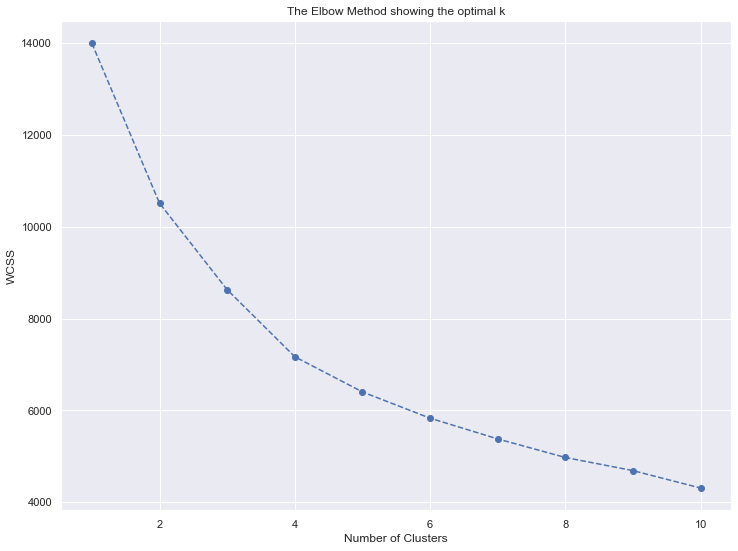

```python
plt.figure(figsize = (12,9))
plt.plot(range(1,11), wcss, marker = 'o', linestyle = '--')
plt.xlabel('Number of Clusters')
plt.ylabel('WCSS')
plt.title('The Elbow Method showing the optimal k')
```

The Elbow method is what would be used to pick the right number of clusters. Clearly, we can observe the elbow at 4. This result agrees with the results from the dendogram so we would use 4 clusters.

##### Model with 4 clusters

```python
# with 4 clusters
kmeans = KMeans(n_clusters= 4, init='k-means++', random_state = 42)
```

```python
# fit with 4 clusters
kmeans.fit(seg_std)
```

```
KMeans(algorithm='auto', copy_x=True, init='k-means++', max_iter=300,
       n_clusters=4, n_init=10, n_jobs=None, precompute_distances='auto',
       random_state=42, tol=0.0001, verbose=0)
```

```python
# predicted labels
kmeans.labels_
```

```
array([0, 3, 1, ..., 1, 3, 1])
```

### Results

```python
# add the clustering results to the data
df_seg_kmeans = df_seg.copy()
# extracting the predicted clusters
df_seg_kmeans['Segment K-means'] = kmeans.labels_
```

```python
#get the characteristics of the people in each of the clusters
#by calculating the mean of each characteristic in each cluster
df_seg_analysis = df_seg_kmeans.groupby(['Segment K-means']).mean()
df_seg_analysis
```

| Segment K-means | Sex | Marital status | Age | Education | Income | Occupation | Settlement size |
| --- | --- | --- | --- | --- | --- | --- | --- |
| 0 | 0.501901 | 0.692015 | 55.703422 | 2.129278 | 158338.422053 | 1.129278 | 1.110266 |
| 1 | 0.352814 | 0.019481 | 35.577922 | 0.746753 | 97859.852814 | 0.329004 | 0.043290 |
| 2 | 0.029825 | 0.173684 | 35.635088 | 0.733333 | 141218.249123 | 1.271930 | 1.522807 |
| 3 | 0.853901 | 0.997163 | 28.963121 | 1.068085 | 105759.119149 | 0.634043 | 0.422695 |

```python
# size and proportions of clusters from the whole dataset
df_seg_analysis['N Obs'] = df_seg_kmeans[['Segment K-means' , 'Age']].groupby(['Segment K-means']).count()
df_seg_analysis['Prop Obs'] = df_seg_analysis['N Obs'] / df_seg_analysis['N Obs'].sum()
```

```python
df_seg_analysis
```

| Segment K-means | Sex | Marital status | Age | Education | Income | Occupation | Settlement size | N Obs | Prop Obs |
| --- | --- | --- | --- | --- | --- | --- | --- | --- | --- |
| 0 | 0.501901 | 0.692015 | 55.703422 | 2.129278 | 158338.422053 | 1.129278 | 1.110266 | 263 | 0.1315 |
| 1 | 0.352814 | 0.019481 | 35.577922 | 0.746753 | 97859.852814 | 0.329004 | 0.043290 | 462 | 0.2310 |
| 2 | 0.029825 | 0.173684 | 35.635088 | 0.733333 | 141218.249123 | 1.271930 | 1.522807 | 570 | 0.2850 |
| 3 | 0.853901 | 0.997163 | 28.963121 | 1.068085 | 105759.119149 | 0.634043 | 0.422695 | 705 | 0.3525 |

```python
df_seg_analysis.rename({0: 'Comfortable',
                        1:'Fewer-oppurtunities',
                        2:'Career Focused',
                       3: 'Standard'})
```

| Segment K-means | Sex | Marital status | Age | Education | Income | Occupation | Settlement size | N Obs | Prop Obs |
| --- | --- | --- | --- | --- | --- | --- | --- | --- | --- |
| Comfortable | 0.501901 | 0.692015 | 55.703422 | 2.129278 | 158338.422053 | 1.129278 | 1.110266 | 263 | 0.1315 |
| Fewer-oppurtunities | 0.352814 | 0.019481 | 35.577922 | 0.746753 | 97859.852814 | 0.329004 | 0.043290 | 462 | 0.2310 |
| Career Focused | 0.029825 | 0.173684 | 35.635088 | 0.733333 | 141218.249123 | 1.271930 | 1.522807 | 570 | 0.2850 |
| Standard | 0.853901 | 0.997163 | 28.963121 | 1.068085 | 105759.119149 | 0.634043 | 0.422695 | 705 | 0.3525 |

#### Interpretation

Cluster 4 takes the biggest share in the data followed by career focused. Now that we have a fair understanding of who the customers are we can start developing strategies on who to reach the needs of each of the groups.

```python
# Visualise the raw data with the clusters
df_seg_kmeans['Labels'] = df_seg_kmeans['Segment K-means'].map({0: 'Comfortable',
                                                                1:'Fewer-oppurtunities',
                                                                2:'Career Focused',
                                                                3:'Standard'})
```

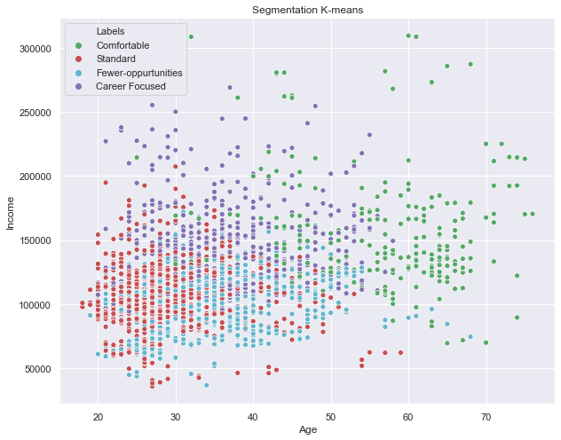

```python
x_axis = df_seg_kmeans['Age']
y_axis = df_seg_kmeans['Income']
plt.figure(figsize = (10, 8))
sns.scatterplot(x_axis, y_axis, hue = df_seg_kmeans['Labels'], palette = ['g', 'r', 'c', 'm'])
plt.title('Segmentation K-means')
plt.show()
```

Our results overlap which makes it impossible to interpret the visuals so we would use Principle Component Analysis reduce the dimensions of our data.

### Principal Component Analysis

Principle component analysis creates as many components as in the data and they are arranged in levels of importance, i.e how much of the variability in the data is explained by each component

```python
pca = PCA()
pca.fit(seg_std)
```

```
PCA(copy=True, iterated_power='auto', n_components=None, random_state=None,
    svd_solver='auto', tol=0.0, whiten=False)
```

```python
pca.explained_variance_ratio_
```

```
array([0.35696328, 0.26250923, 0.18821114, 0.0755775 , 0.05716512,
       0.03954794, 0.02002579])
```

From the above output, you can observe that the principal component 1 holds 35.7.2% of the information while the principal component 2 holds only 26.3% of the information. Also, the other point to note is that while projecting dimension some information would be lost.

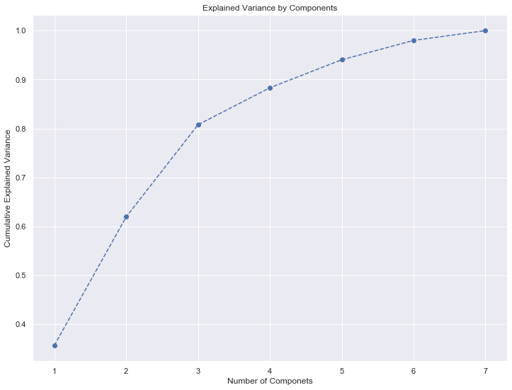

```python
# picking the best components
plt.figure(figsize=(12,9))
plt.plot(range(1,8),pca.explained_variance_ratio_.cumsum(), marker = 'o', linestyle='--')
plt.title('Explained Variance by Components')
plt.xlabel('Number of Componets')
plt.ylabel('Cumulative Explained Variance')
```

#### Interpretation

The rule of thump is to preserve 70 to 80% of the variance, so we would use 3 principle components.

#### Using 3 components

```python
pca = PCA(n_components = 3)
```

```python
pca.fit(seg_std)
```

```
PCA(copy=True, iterated_power='auto', n_components=3, random_state=None,
    svd_solver='auto', tol=0.0, whiten=False)
```

### PCA Results using 3 components

```python
pca.components_
```

```
array([[-0.31469524, -0.19170439,  0.32609979,  0.15684089,  0.52452463,
         0.49205868,  0.46478852],
       [ 0.45800608,  0.51263492,  0.31220793,  0.63980683,  0.12468314,
         0.01465779, -0.06963165],
       [-0.29301261, -0.44197739,  0.60954372,  0.27560461, -0.16566231,
        -0.39550539, -0.29568503]])
```

The above ratios are the loadings : correlation between an original variable and a component. Here we have 3 arrays of loadings for 3 components.

```python
# lets put this in a dataframe for better understanding
df_pca_comp = pd.DataFrame(data = pca.components_,
                          columns = df_seg.columns.values,
                          index = ['Component 1', 'Component 2', 'Component 3'])
df_pca_comp
```

|  | Sex | Marital status | Age | Education | Income | Occupation | Settlement size |
| --- | --- | --- | --- | --- | --- | --- | --- |
| Component 1 | -0.314695 | -0.191704 | 0.326100 | 0.156841 | 0.524525 | 0.492059 | 0.464789 |
| Component 2 | 0.458006 | 0.512635 | 0.312208 | 0.639807 | 0.124683 | 0.014658 | -0.069632 |
| Component 3 | -0.293013 | -0.441977 | 0.609544 | 0.275605 | -0.165662 | -0.395505 | -0.295685 |

The closer to zero the ratio the lower the loading onto a component.

[output not shown]

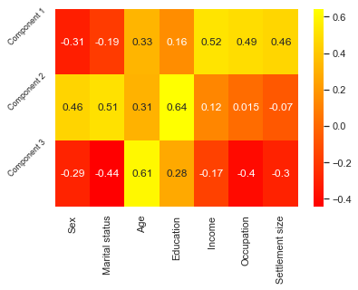

```python
# lets Visualise
sns.heatmap(df_pca_comp,
           cmap = "autumn",
           annot = True)
plt.yticks([0,1,2],
         ['Component 1', 'Component 2', 'Component 3'],
          rotation = 45,
          fontsize = 9)
```

#### Interpretation

1. Component 1 - The first component focuses on the Career of the customers, we can observe this from the strong correlations in the plot above
2. Component 2 - The focus here is on Education and Life style
3. Component 3 - The focus here is Life and work experience

```python
# transform the data to 3 dimention
pca.transform(seg_std)
```

```
array([[ 2.51474593,  0.83412239,  2.1748059 ],
       [ 0.34493528,  0.59814564, -2.21160279],
       [-0.65106267, -0.68009318,  2.2804186 ],
       ...,
       [-1.45229829, -2.23593665,  0.89657125],
       [-2.24145254,  0.62710847, -0.53045631],
       [-1.86688505, -2.45467234,  0.66262172]])
```

```python
# store the results in scores_pca
scores_pca = pca.transform(seg_std)
```

## K-means clustering with PCA

```python
wcss=[] # within clusster sum of squares
for i in range (1,11): # create a loop for of clusters that run from 1 to 10
    kmeans_pca = KMeans(n_clusters= i, init='k-means++', random_state = 42)
    kmeans_pca.fit(scores_pca)
    wcss.append(kmeans_pca.inertia_)
```

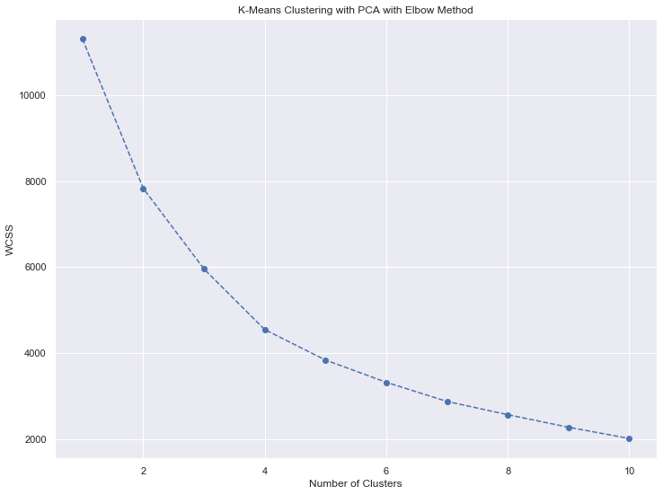

```python
plt.figure(figsize = (12,9))
plt.plot(range(1,11), wcss, marker = 'o', linestyle = '--')
plt.xlabel('Number of Clusters')
plt.ylabel('WCSS')
plt.title('K-Means Clustering with PCA with Elbow Method')
```

We would be working with 4 clusters again.

```python
kmeans_pca = KMeans(n_clusters= 4, init='k-means++', random_state = 42)
```

```python
# fit the model
kmeans_pca.fit(scores_pca)
```

```
KMeans(algorithm='auto', copy_x=True, init='k-means++', max_iter=300,
       n_clusters=4, n_init=10, n_jobs=None, precompute_distances='auto',
       random_state=42, tol=0.0001, verbose=0)
```

### Results

```python
# append the componets to the dataset
df_seg_pca_kmeans = pd.concat([df_seg.reset_index(drop = True), pd.DataFrame(scores_pca)], axis = 1)
df_seg_pca_kmeans.columns.values[-3: ] = ['Component 1', 'Component 2', 'Component 3']
df_seg_pca_kmeans['Segment K-means PCA'] = kmeans_pca.labels_
```

```python
df_seg_pca_kmeans
```

|  | Sex | Marital status | Age | Education | Income | Occupation | Settlement size | Component 1 | Component 2 | Component 3 | Segment K-means PCA |
| --- | --- | --- | --- | --- | --- | --- | --- | --- | --- | --- | --- |
| 0 | 0 | 0 | 67 | 2 | 124670 | 1 | 2 | 2.514746 | 0.834122 | 2.174806 | 0 |
| 1 | 1 | 1 | 22 | 1 | 150773 | 1 | 2 | 0.344935 | 0.598146 | -2.211603 | 2 |
| 2 | 0 | 0 | 49 | 1 | 89210 | 0 | 0 | -0.651063 | -0.680093 | 2.280419 | 1 |
| 3 | 0 | 0 | 45 | 1 | 171565 | 1 | 1 | 1.714316 | -0.579927 | 0.730731 | 3 |
| 4 | 0 | 0 | 53 | 1 | 149031 | 1 | 1 | 1.626745 | -0.440496 | 1.244909 | 3 |
| ... | ... | ... | ... | ... | ... | ... | ... | ... | ... | ... | ... |
| 1995 | 1 | 0 | 47 | 1 | 123525 | 0 | 0 | -0.866034 | 0.298330 | 1.438958 | 1 |
| 1996 | 1 | 1 | 27 | 1 | 117744 | 1 | 0 | -1.114957 | 0.794727 | -1.079871 | 2 |
| 1997 | 0 | 0 | 31 | 0 | 86400 | 0 | 0 | -1.452298 | -2.235937 | 0.896571 | 1 |
| 1998 | 1 | 1 | 24 | 1 | 97968 | 0 | 0 | -2.241453 | 0.627108 | -0.530456 | 2 |
| 1999 | 0 | 0 | 25 | 0 | 68416 | 0 | 0 | -1.866885 | -2.454672 | 0.662622 | 1 |

2000 rows × 11 columns

```python
# calculate the mean of each features by clusters
df_seg_pca_kmeans_freq = df_seg_pca_kmeans.groupby(['Segment K-means PCA']).mean()
df_seg_pca_kmeans_freq
```

| Segment K-means PCA | Sex | Marital status | Age | Education | Income | Occupation | Settlement size | Component 1 | Component 2 | Component 3 |
| --- | --- | --- | --- | --- | --- | --- | --- | --- | --- | --- |
| 0 | 0.503788 | 0.689394 | 55.689394 | 2.128788 | 158209.094697 | 1.125000 | 1.106061 | 1.697646 | 2.029427 | 0.841953 |
| 1 | 0.305011 | 0.095861 | 35.315904 | 0.760349 | 93633.372549 | 0.250545 | 0.039216 | -1.047610 | -0.904856 | 1.005493 |
| 2 | 0.900576 | 0.963977 | 28.920749 | 1.061960 | 107571.126801 | 0.677233 | 0.439481 | -1.106034 | 0.705300 | -0.776925 |
| 3 | 0.027444 | 0.168096 | 35.737564 | 0.734134 | 141525.826758 | 1.267581 | 1.480274 | 1.372663 | -1.046172 | -0.248046 |

```python
# size and proportions of clusters from the whole dataset to find how many people belong to each cluster
df_seg_pca_kmeans_freq['N Obs'] = df_seg_pca_kmeans[['Segment K-means PCA' , 'Age']].groupby(['Segment K-means PCA']).count()
df_seg_pca_kmeans_freq['Prop Obs'] = df_seg_pca_kmeans_freq['N Obs'] / df_seg_pca_kmeans_freq['N Obs'].sum()
df_seg_pca_kmeans_freq= df_seg_pca_kmeans_freq.rename({0:'Comfortable',
                        1:'Fewer-oppurtunities',
                        2:'Standard',
                        3:'Career Focused'})
df_seg_pca_kmeans_freq
```

| Segment K-means PCA | Sex | Marital status | Age | Education | Income | Occupation | Settlement size | Component 1 | Component 2 | Component 3 | N Obs | Prop Obs |
| --- | --- | --- | --- | --- | --- | --- | --- | --- | --- | --- | --- | --- |
| Comfortable | 0.503788 | 0.689394 | 55.689394 | 2.128788 | 158209.094697 | 1.125000 | 1.106061 | 1.697646 | 2.029427 | 0.841953 | 264 | 0.1320 |
| Fewer-oppurtunities | 0.305011 | 0.095861 | 35.315904 | 0.760349 | 93633.372549 | 0.250545 | 0.039216 | -1.047610 | -0.904856 | 1.005493 | 459 | 0.2295 |
| Standard | 0.900576 | 0.963977 | 28.920749 | 1.061960 | 107571.126801 | 0.677233 | 0.439481 | -1.106034 | 0.705300 | -0.776925 | 694 | 0.3470 |
| Career Focused | 0.027444 | 0.168096 | 35.737564 | 0.734134 | 141525.826758 | 1.267581 | 1.480274 | 1.372663 | -1.046172 | -0.248046 | 583 | 0.2915 |

```python
df_seg_pca_kmeans['Legend'] = df_seg_pca_kmeans['Segment K-means PCA'].map({0:'Comfortable',
                        1:'Fewer-oppurtunities',
                        2:'Standard',
                        3:'Career Focused'})
```

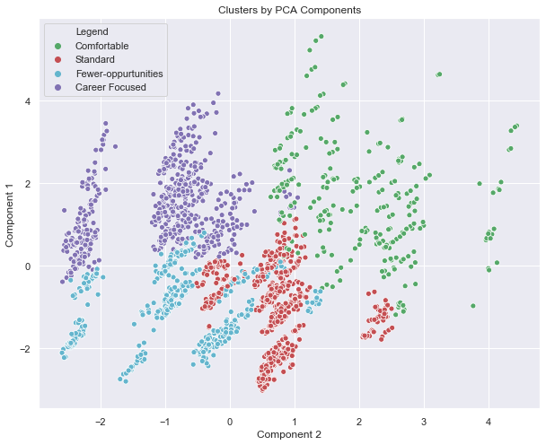

```python
# Visualise the segments with respect to the first 2 components
x_axis = df_seg_pca_kmeans['Component 2']
y_axis = df_seg_pca_kmeans['Component 1']
plt.figure(figsize = (10, 8))
sns.scatterplot(x_axis, y_axis, hue = df_seg_pca_kmeans['Legend'], palette = ['g', 'r', 'c', 'm'])
plt.title('Clusters by PCA Components')
plt.show()
```

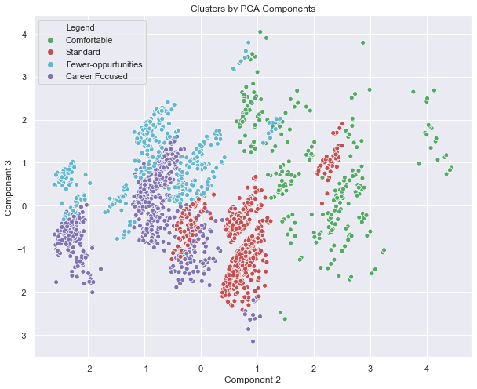

```python
x_axis = df_seg_pca_kmeans['Component 2']
y_axis = df_seg_pca_kmeans['Component 3']
plt.figure(figsize = (10, 8))
sns.scatterplot(x_axis, y_axis, hue = df_seg_pca_kmeans['Legend'], palette = ['g', 'r', 'c', 'm'])
plt.title('Clusters by PCA Components')
plt.show()
```

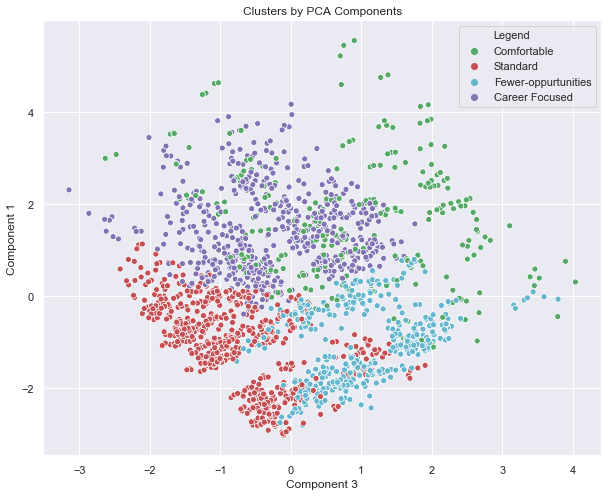

```python
x_axis = df_seg_pca_kmeans['Component 3']
y_axis = df_seg_pca_kmeans['Component 1']
plt.figure(figsize = (10, 8))
sns.scatterplot(x_axis, y_axis, hue = df_seg_pca_kmeans['Legend'], palette = ['g', 'r', 'c', 'm'])
plt.title('Clusters by PCA Components')
plt.show()
```

#### Interpretation

Using 3 components to reduce the dimensions we can properly visualize the data but there is still some overlapping in the data so we can try to reduce the dimensions further for better results.

```python
# data export
pickle.dump(scaler, open('scaler.pickle', 'wb'))
```

```python
pickle.dump(pca, open('pca.pickle', 'wb'))
```

```python
pickle.dump(kmeans_pca, open('kmeans_pca.pickle', 'wb'))
```